# Example Report Template for a Data Analysis Project

## 3.2 Basic statistical analysis

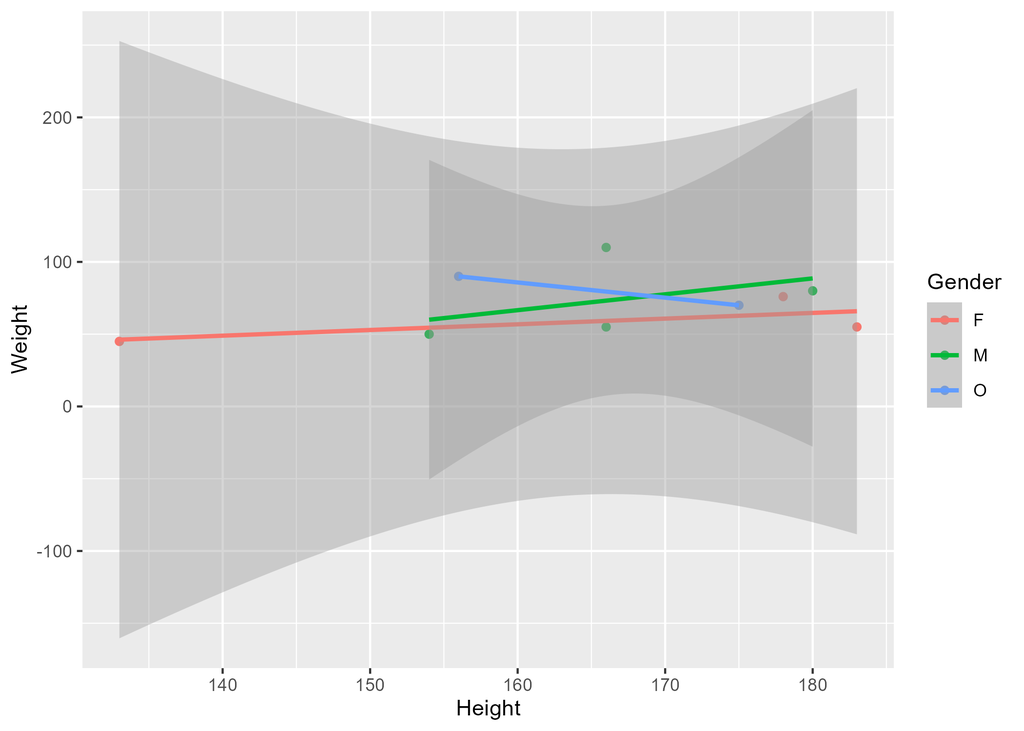

Figure 1: Height and weight stratified by gender.

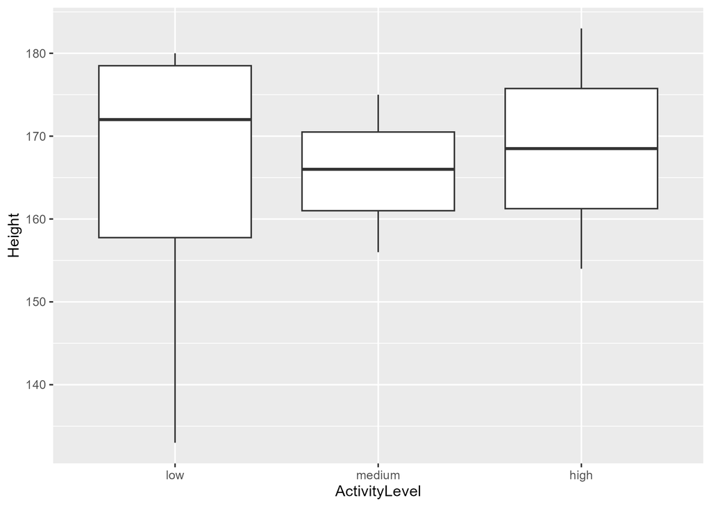

Figure 2: Height distribution across activity level categories.

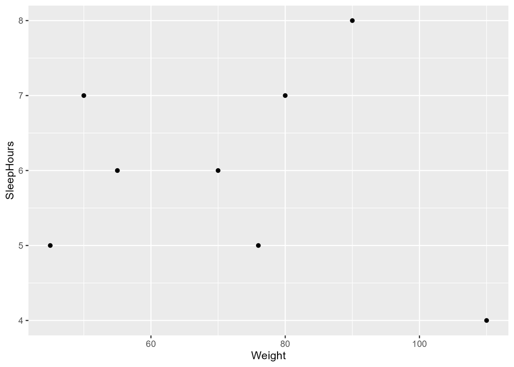

Figure 3: Scatter plot of sleep duration versus weight.

We next applied linear regression models to further examine relationships between height and potential predictors. These models allow us to assess whether variables are associated with height.

## 3.3 Full analysis

Summary of a linear model fit.

Table 2: Linear model fit table.

| term | estimate | std.error | statistic | p.value |
| --- | --- | --- | --- | --- |
| (Intercept) | 149.2726967 | 23.3823360 | 6.3839942 | 0.0013962 |
| Weight | 0.2623972 | 0.3512436 | 0.7470519 | 0.4886517 |
| GenderM | -2.1244913 | 15.5488953 | -0.1366329 | 0.8966520 |
| GenderO | -4.7644739 | 19.0114155 | -0.2506112 | 0.8120871 |

Table 3: Linear regression predicting Height from SleepHours and ActivityLevel.

| term | estimate | std.error | statistic | p.value |
| --- | --- | --- | --- | --- |
| (Intercept) | 166.9578947 | 38.786998 | 4.3044810 | 0.0076827 |
| SleepHours | -0.5157895 | 7.136227 | -0.0722776 | 0.9451831 |
| ActivityLevelmedium | 2.1473684 | 18.367989 | 0.1169082 | 0.9114836 |
| ActivityLevelhigh | 4.8947368 | 19.543363 | 0.2504552 | 0.8122012 |

In this dataset, linear regression models did not reveal strong evidence of associations between height and the examined predictors.

# 4 Discussion

In this exploratory analysis, linear regression models did not reveal strong evidence of associations, likely due to the limited sample size which reduces statistical power.

# 5 Conclusions

This analysis demonstrated a reproducible workflow for exploratory data analysis and basic statistical modeling. While no strong associations were detected, the approach illustrates how visualizations and regression models can be used to explore relationships in datasets.